# entrega_final

agustin ianchina

12/2/2022

# Depuración training

## Setup y carga de datos

```r
chooseCRANmirror(graphics=FALSE, ind=1)
knitr::opts_chunk$set(echo = TRUE)

# working directory
setwd('C:/Users/Agustin Ianchina/OneDrive/Documents/Master UCM/6-Mineria de Datos(predictiva)')

# funciones
source("Funciones_R.R")

# datos
datos = readRDS("Tarea/FugaClientes_Training.rds")

#paquetes
paquetes(c('questionr','psych','car','corrplot','ggplot2',"gridExtra",'kableExtra','dplyr','DMwR2', 'tidyr','caret','lmSupport','pROC','glmnet'))
```

## Exploración

```r
names(datos)
```

```r
str(datos)
```

```r
psych::describe(datos)
```

```r
summary(datos)
```

```
##           ID          Genero     Mayor65     Conyuge    PersCargo
##  0002-ORFBO:   1   Female:2963   0   :5045   No :3287   No :4439
##  0003-MKNFE:   1   Male  :3038   1   : 956   Yes:3066   Yes:1914
##  0004-TLHLJ:   1   NA's  : 352   NA's: 352
##  0011-IGKFF:   1
##  0013-EXCHZ:   1
##  0013-MHZWF:   1
##  (Other)   :6347
##  Antig.fc.edad   Telf_serv   VariasLineas        Int_serv    Seguridad
##  Min.   : 0.00   No  : 605   No :3687     DSL        :2122   No :4532
##  1st Qu.: 9.00   Yes :5656   Yes:2666     Fiber optic:2702   Yes:1821
##  Median :29.00   NA's:  92                No         :1339
##  Mean   :32.38                            NA's       : 190
##  3rd Qu.:55.00
##  Max.   :72.00
##  NA's   :394
##  CopiaSeguridad Antivirus_disp Soporte_tecnico TV_streaming Peliculas
##  No :4180       No :4180       No :4509        No :3936     No :3902
##  Yes:2173       Yes:2173       Yes:1844        Yes:2417     Yes:2451
##
##
##
##
##
##            Contrato    Fact_sinPapel                     MetodoPago
##  Month-to-month:3285   No  :2483     Bank transfer (automatic):1283
##  One year      :1261   Yes :3609     Credit card (automatic)  :1290
##  Two year      :1413   NA's: 261     Electronic check         :1972
##  NA's          : 394                 Mailed check             :1336
##                                      NA's                     : 472
##
##
##    FacturaMes      FacturaTotal    Fuga
##  Min.   : 18.25   Min.   :  18.8   0:4667
##  1st Qu.: 35.55   1st Qu.: 394.5   1:1686
##  Median : 70.30   Median :1384.2
##  Mean   : 64.68   Mean   :2268.7
##  3rd Qu.: 89.80   3rd Qu.:3781.5
##  Max.   :118.75   Max.   :8672.5
##  NA's   :394      NA's   :11
```

NA’s Genero: Se presume que los datos faltantes en este campo no son por un error si no porque el cliente decidió no comunicarlo. Crear categoría “Prefer not say”. Mayor 65: Se presume dato faltante por error. Antig.fc.edad: Se presume dato faltante por error. Telf_serv: Se presume dato faltante por error. Int_serv: Se presume dato faltante por error. Contrato: Se presume dato faltante por error. Fact_sinPapel: Se presume dato faltante por error. MetododePago: Se presume dato faltante por error. FacturaMes: Se presume dato faltante por error. FacturaTotal: Se presume dato faltante por error.

Se chequean los registros únicos para los campos numéricos.

```r
sapply(Filter(is.numeric, datos),function(x) length(unique(x)))
```

```
## Antig.fc.edad    FacturaMes  FacturaTotal
##            74          1523          5924
```

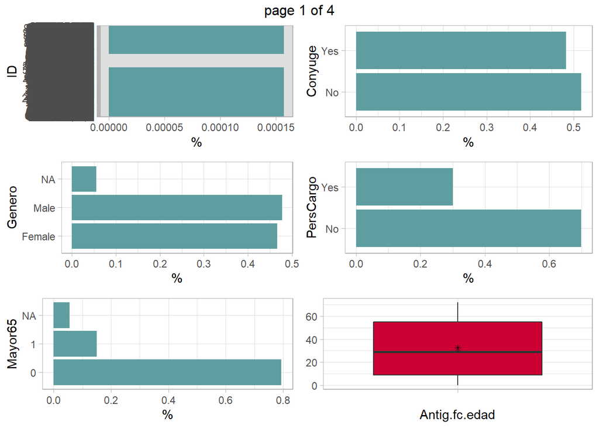

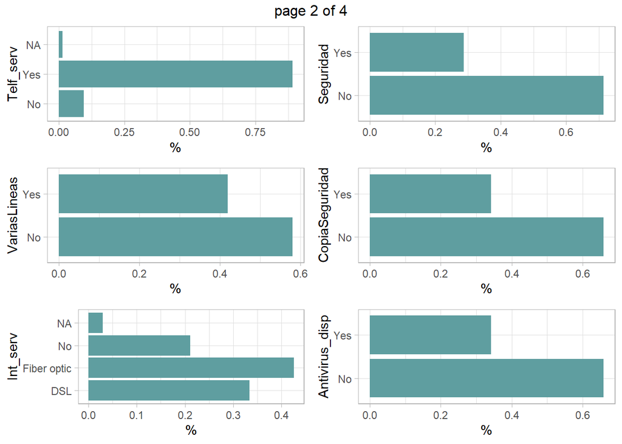

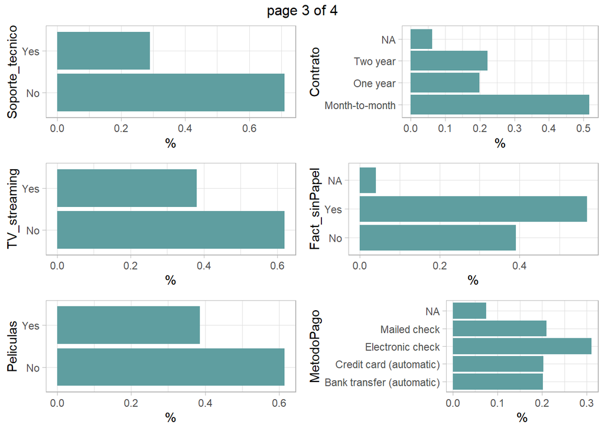

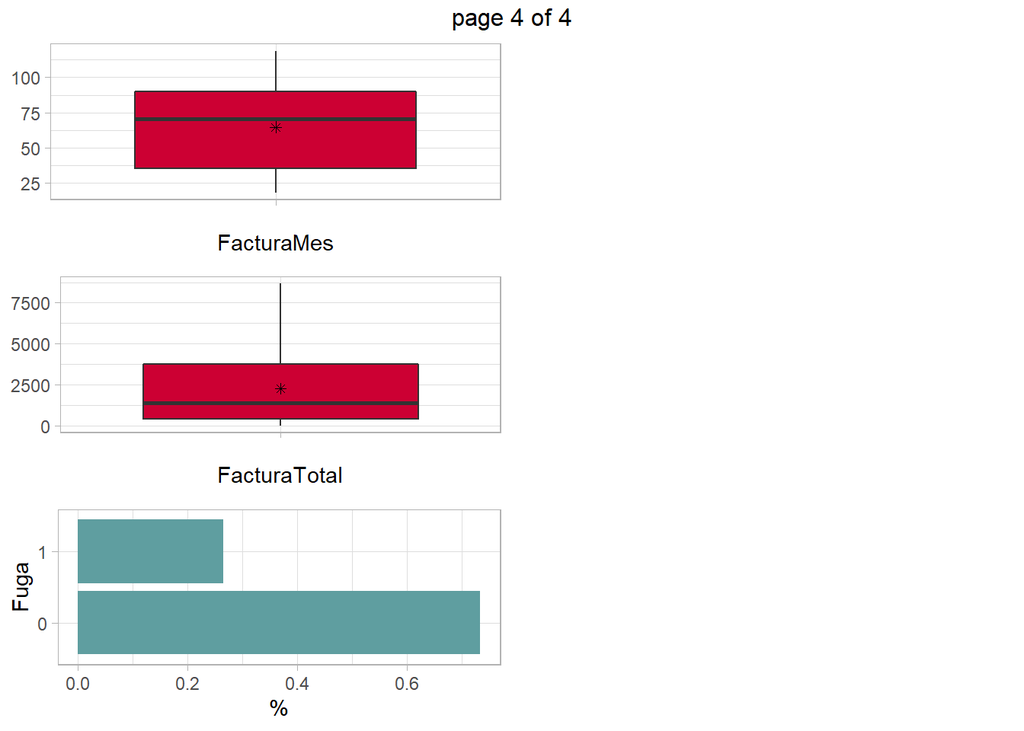

```r
listaGraf <- dfplot_box(datos) #Boxplots
listaHist<-dfplot_his(datos) #Histogramas

gridExtra::marrangeGrob(listaGraf, nrow = 3, ncol = 2)
```

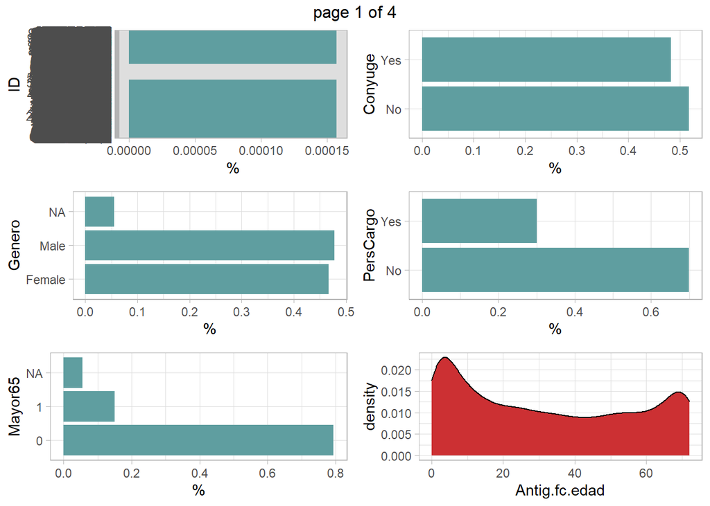

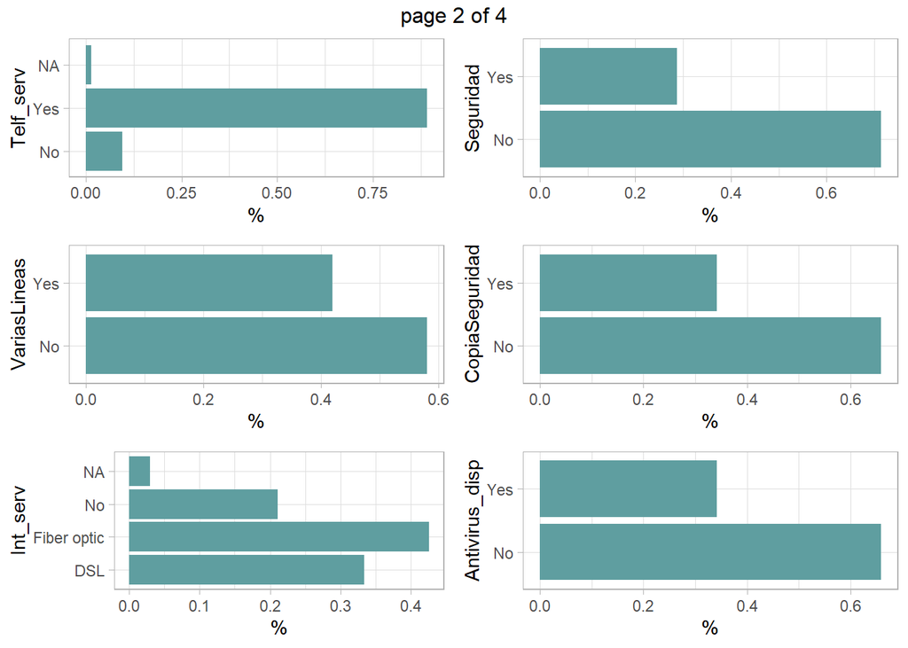

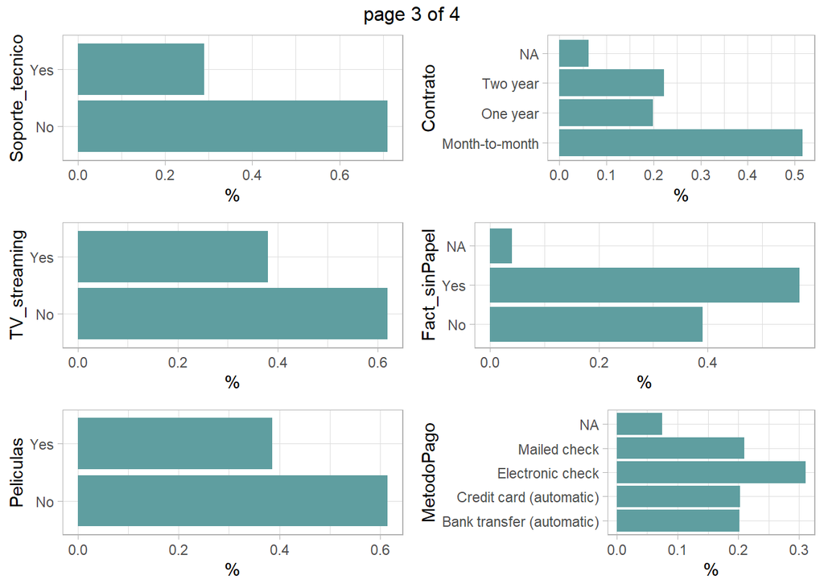

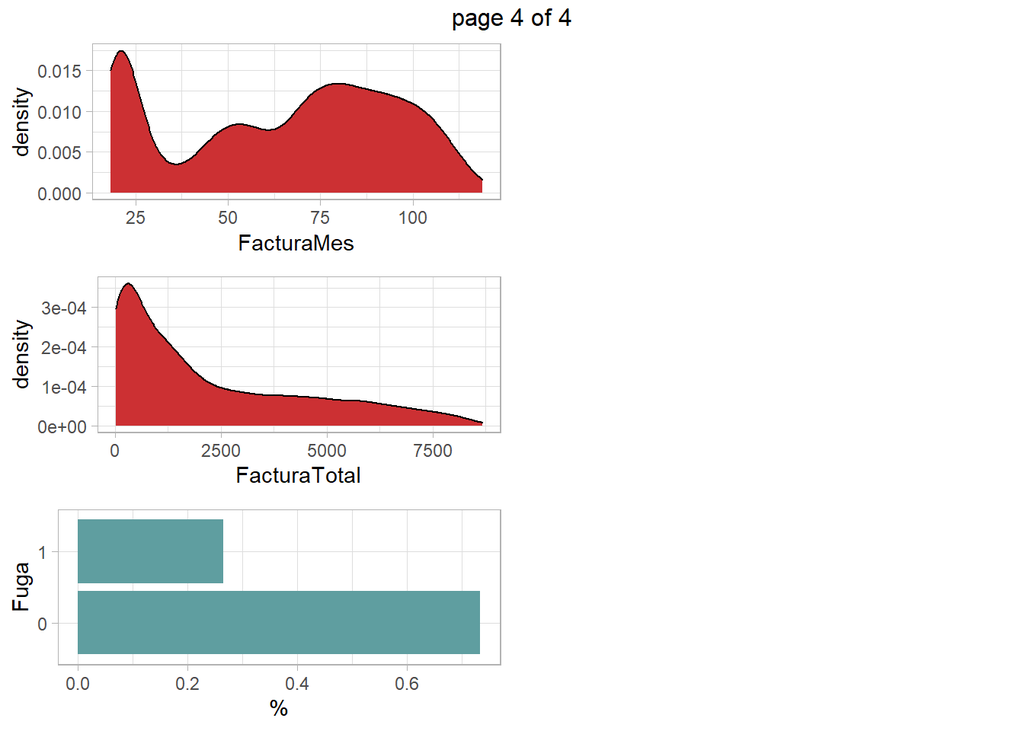

```r
gridExtra::marrangeGrob(listaHist, nrow = 3, ncol = 2)
```

```r
#corrección género
levels(datos$Genero) = c(levels(datos$Genero), "PreferNotSay") #se adiciona el factor
datos$Genero<-replace(datos$Genero,which(is.na(datos$Genero)),'PreferNotSay') #se reemplazas los NA por el nuevo factor
summary(datos$Genero) #se verifica que haya funcionado
```

```
##       Female         Male PreferNotSay
##         2963         3038          352
```

```r
#los atípicos y missing se gestionan sólo para los inputs
varObjBin = datos$Fuga
input = as.data.frame(datos[1:20])
```

## Outliers

Outliers candidatos Observando las distribuciones, y los boxplot: FacturaTotal se ve muy sesgada, con cola hacia a la derecha. No se ven outliers en los boxplots. Antig.fc.edad se ve bimodal, y bastante plana. No se ven outliers en los boxplots. FacturaMes no se ve con cola hacian ningún lado. No se ven outliers en los boxplots.

Se aplica la función atipicosAmissing.

```r
sapply(Filter(is.numeric, input),
       function(x) atipicosAmissing(x)[[2]])/nrow(input)
```

```
## Antig.fc.edad    FacturaMes  FacturaTotal
##             0             0             0
```

```r
t<-data.frame(sort(
  round(sapply(Filter(
    is.numeric, input),function(nOut) atipicosAmissing(
      nOut)[[2]])/nrow(input)*100,3), decreasing = T))
names(t)<-"% Outliers por variable"
t
```

```
##               % Outliers por variable
## Antig.fc.edad                       0
## FacturaMes                          0
## FacturaTotal                        0
```

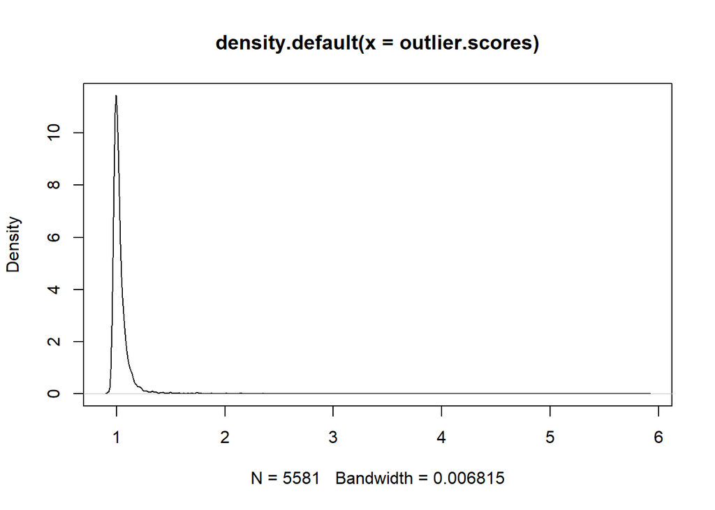

```r
outlier.scores <- lofactor(na.omit(Filter(is.numeric, input)), k=20)
plot(density(outlier.scores))
```

```r
outliers <- order(outlier.scores, decreasing=T)
#na.omit(Filter(is.numeric, input))[outliers,]
```

## Missings

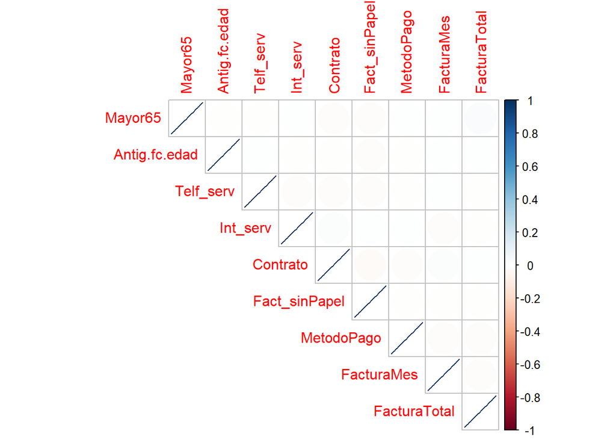

```r
corrplot(cor(is.na(input[colnames(
  input)[colSums(is.na(input))>0]])),method = "ellipse",type = "upper")
```

```r
prop_missingsVars<-apply(is.na(input),2,mean) # Por variable

# Tabla para el % de missing por variable
t<-data.frame(sort(prop_missingsVars*100, decreasing = T))
names(t)<-"% Missing por Variable"
t
```

```
##                 % Missing por Variable
## MetodoPago                   7.4295608
## Antig.fc.edad                6.2017944
## Contrato                     6.2017944
## FacturaMes                   6.2017944
## Mayor65                      5.5406894
## Fact_sinPapel                4.1082953
## Int_serv                     2.9907130
## Telf_serv                    1.4481347
## FacturaTotal                 0.1731465
## ID                           0.0000000
## Genero                       0.0000000
## Conyuge                      0.0000000
## PersCargo                    0.0000000
## VariasLineas                 0.0000000
## Seguridad                    0.0000000
## CopiaSeguridad               0.0000000
## Antivirus_disp               0.0000000
## Soporte_tecnico              0.0000000
## TV_streaming                 0.0000000
## Peliculas                    0.0000000
```

El % de valores perdidos por variable es menor a 8% para todos los campos, es decir, son valores bajos y razonables.

```r
input$prop_missings<-apply(is.na(input),1,mean) # Por observación
summary(input$prop_missings)
```

```
##    Min. 1st Qu.  Median    Mean 3rd Qu.    Max.
## 0.00000 0.00000 0.00000 0.02015 0.05000 0.15000
```

Se observa que ningún registro presenta más de la mitad de sus campos perdidos, por ende no haría falta eliminar ningún registro.

```r
input %>% arrange(desc(prop_missings))
```

## Imputaciones:

Se corren tres veces para asegurarse. (según lo visto en los videos de las clases)

```r
input[,as.vector(which(sapply(input, class)=="numeric"))]<-sapply(
  Filter(is.numeric, input),function(x) ImputacionCuant(x,"aleatorio"))

input[,as.vector(which(sapply(input, class)=="factor"))]<-sapply(
  Filter(is.factor, input),function(x) ImputacionCuali(x,"aleatorio"))

prop_missingsVars<-apply(is.na(input),2,mean) # Por variable

# Tabla bonita para el % de missing por variable
t<-data.frame(sort(prop_missingsVars*100, decreasing = T))
names(t)<-"% Missing por Variable"
t

input$prop_missings<-apply(is.na(input),1,mean) # Por observación
summary(input$prop_missings) #se corrobora que de 0
```

```r
input[,as.vector(which(sapply(input, class)=="numeric"))]<-sapply(
  Filter(is.numeric, input),function(x) ImputacionCuant(x,"aleatorio"))
input[,as.vector(which(sapply(input, class)=="factor"))]<-sapply(
  Filter(is.factor, input),function(x) ImputacionCuali(x,"aleatorio"))

prop_missingsVars<-apply(is.na(input),2,mean) # Por variable

# Tabla bonita para el % de missing por variable
t<-data.frame(sort(prop_missingsVars*100, decreasing = T))
names(t)<-"% Missing por Variable"
t

input$prop_missings<-apply(is.na(input),1,mean) # Por observación
summary(input$prop_missings) #se corrobora que de 0
```

```r
input[,as.vector(which(sapply(input, class)=="numeric"))]<-sapply(
  Filter(is.numeric, input),function(x) ImputacionCuant(x,"aleatorio"))

input[,as.vector(which(sapply(input, class)=="factor"))]<-sapply(
  Filter(is.factor, input),function(x) ImputacionCuali(x,"aleatorio"))

prop_missingsVars<-apply(is.na(input),2,mean) # Por variable

# Tabla bonita para el % de missing por variable
t<-data.frame(sort(prop_missingsVars*100, decreasing = T))
names(t)<-"% Missing por Variable"
t
```

```
##                 % Missing por Variable
## ID                                   0
## Genero                               0
## Mayor65                              0
## Conyuge                              0
## PersCargo                            0
## Antig.fc.edad                        0
## Telf_serv                            0
## VariasLineas                         0
## Int_serv                             0
## Seguridad                            0
## CopiaSeguridad                       0
## Antivirus_disp                       0
## Soporte_tecnico                      0
## TV_streaming                         0
## Peliculas                            0
## Contrato                             0
## Fact_sinPapel                        0
## MetodoPago                           0
## FacturaMes                           0
## FacturaTotal                         0
## prop_missings                        0
```

```r
input$prop_missings<-apply(is.na(input),1,mean) # Por observación
summary(input$prop_missings) #se corrobora que de 0
```

```
##    Min. 1st Qu.  Median    Mean 3rd Qu.    Max.
##       0       0       0       0       0       0
```

```r
saveRDS(cbind(varObjBin,input),"datosdep.RDS")
```

# Depuración test

## Setup y carga de datos

```r
# working directory
setwd('C:/Users/Agustin Ianchina/OneDrive/Documents/Master UCM/6-Mineria de Datos(predictiva)')
# datos
datos = readRDS("Tarea/FugaClientes_test.rds")
```

## Exploración

```r
names(datos)
```

```r
str(datos)
```

```r
psych::describe(datos)
```

```r
summary(datos)
```

```r
sapply(Filter(is.numeric, datos),function(x) length(unique(x)))
```

```r
#corrección género
levels(datos$Genero) = c(levels(datos$Genero), "PreferNotSay") #se adiciona el factor
datos$Genero<-replace(datos$Genero,which(is.na(datos$Genero)),'PreferNotSay') #se reemplazas los NA por el nuevo factor
summary(datos$Genero) #se verifica que haya funcionado
```

```
##    Length     Class      Mode
##       690 character character
```

```r
#correción Mayor65 type
datos$Mayor65<-as.factor(datos$Mayor65)
```

```r
input = as.data.frame(datos)
```

```r
saveRDS(input,"datosdep_test.RDS")
```

# Modelos

## carga de datos y exploración

```r
datos<-readRDS("C:/Users/Agustin Ianchina/OneDrive/Documents/Master UCM/6-Mineria de Datos(predictiva)/Tarea/datosdep.RDS")

varObjBin<-datos$varObjBin
input<-datos[,-(1:1)]
input = strings2factors(input)
str(input)
```

```r
# Creo la variable aleatoria
input$aleatorio<-runif(nrow(input))

input$aleatorio2<-runif(nrow(input))
```

[figure not shown]

```r
graficoVcramer(input,varObjBin)
```

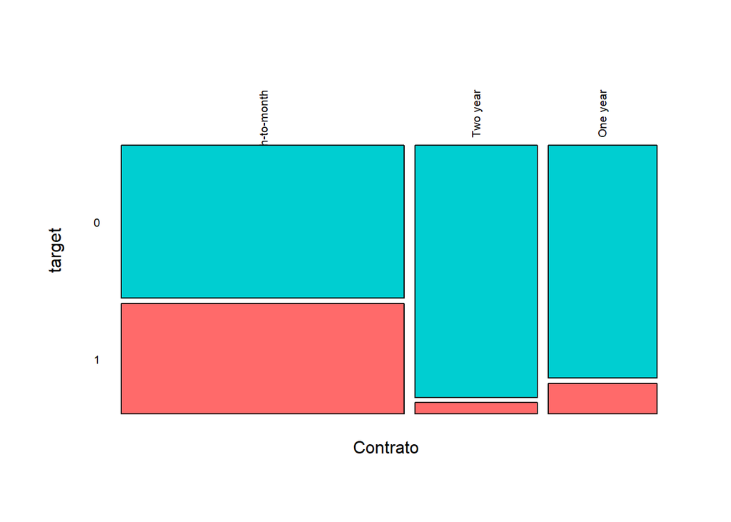

```r
#Veo gráficamente el efecto de dos variables cualitativas sobre la binaria
m1<-mosaico_targetbinaria(input$Contrato,varObjBin,"Contrato")
```

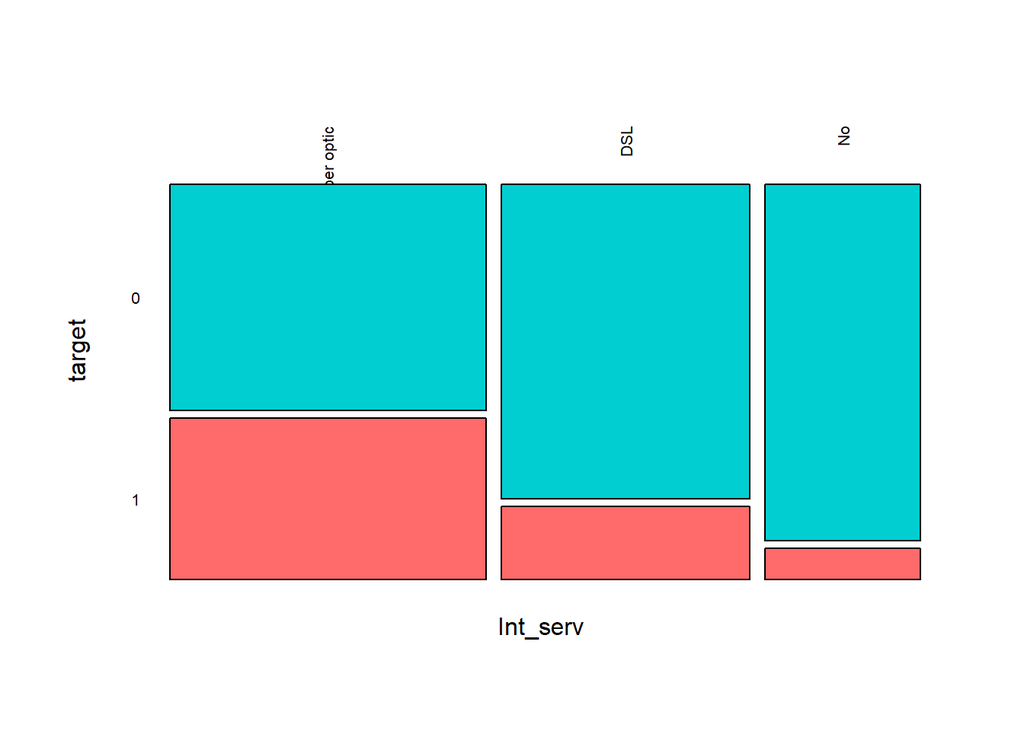

```r
m2<-mosaico_targetbinaria(input$Int_serv,varObjBin,"Int_serv")
```

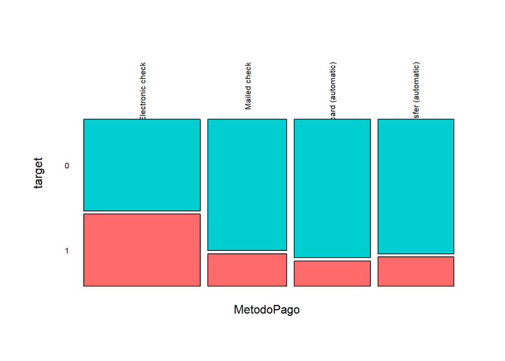

```r
m3<-mosaico_targetbinaria(input$MetodoPago,varObjBin,"MetodoPago")
```

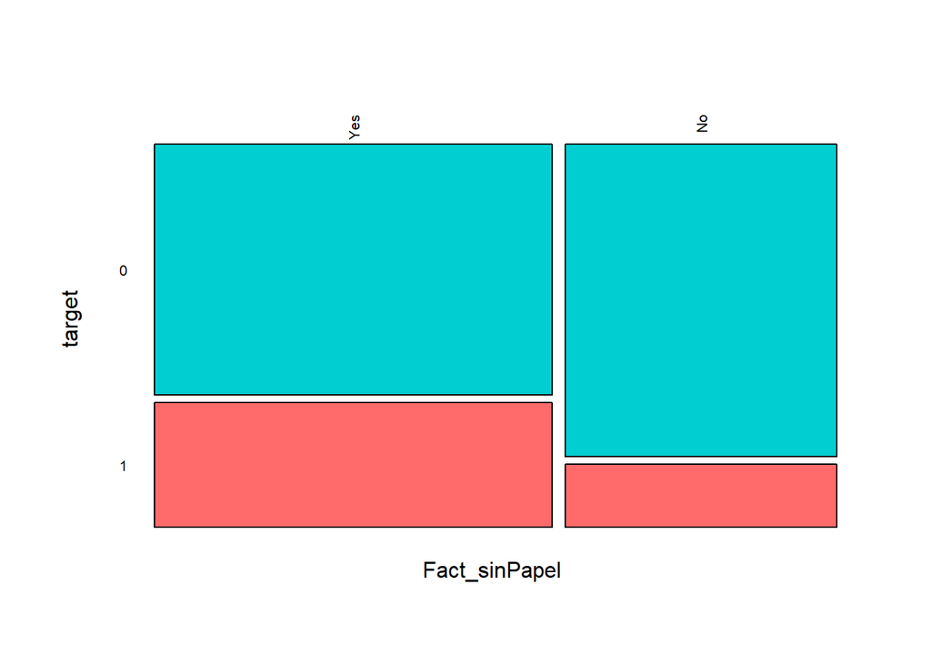

```r
m4<-mosaico_targetbinaria(input$Fact_sinPapel,varObjBin,"Fact_sinPapel")
```

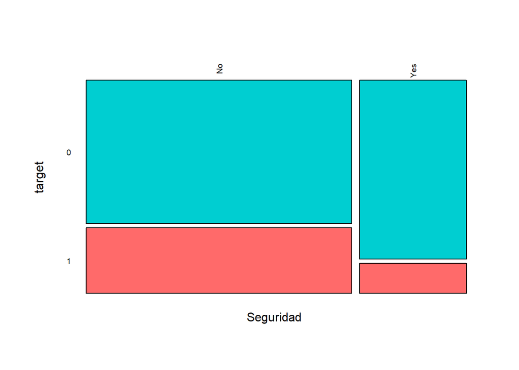

```r
m5<-mosaico_targetbinaria(input$Seguridad,varObjBin,"Seguridad")
```

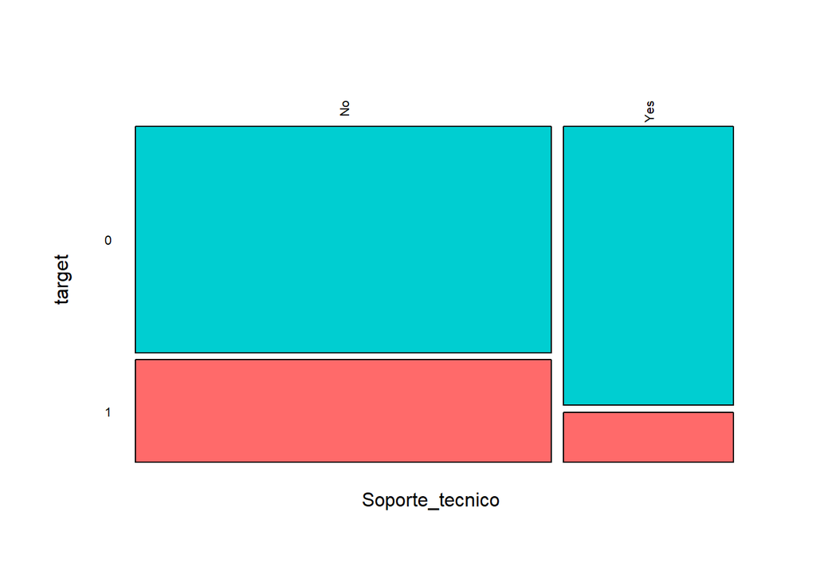

```r
m6<-mosaico_targetbinaria(input$Soporte_tecnico,varObjBin,"Soporte_tecnico")
```

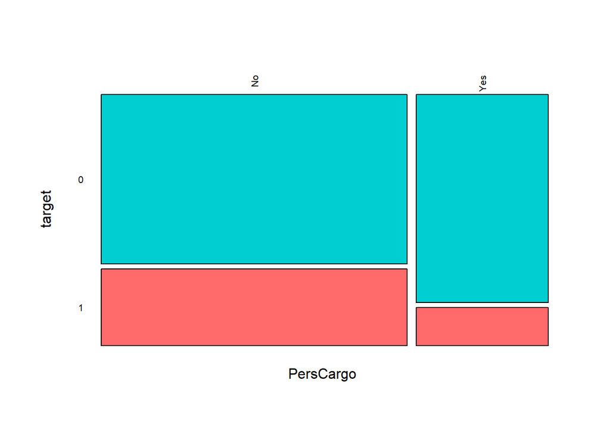

```r
m7<-mosaico_targetbinaria(input$PersCargo,varObjBin,"PersCargo")
```

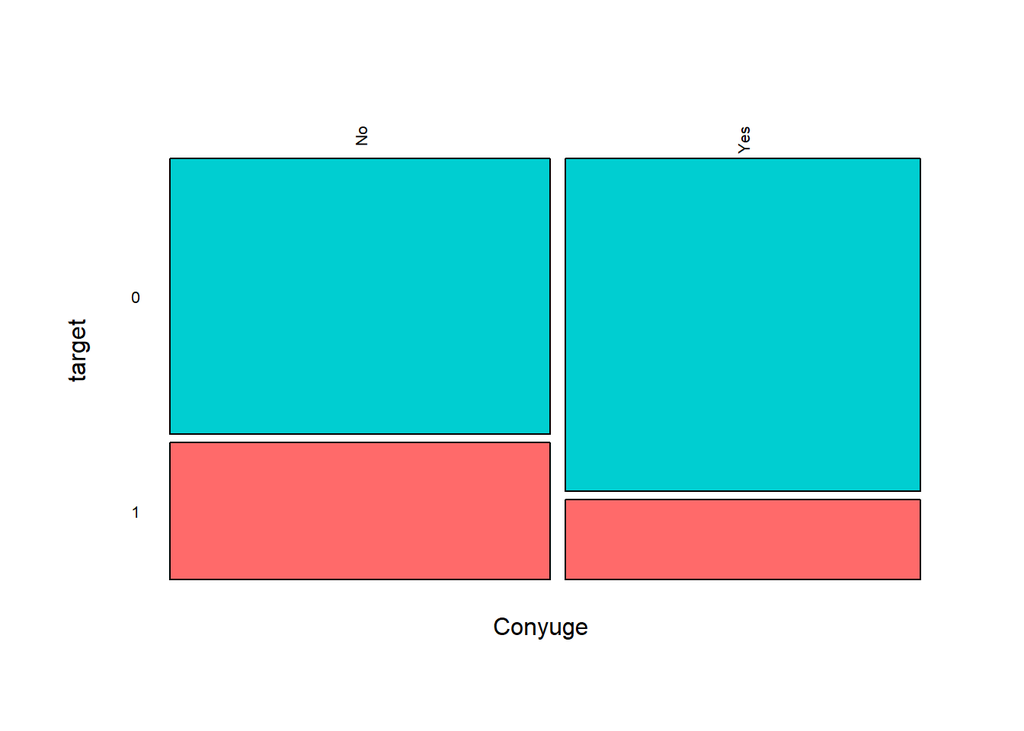

```r
m8<-mosaico_targetbinaria(input$Conyuge,varObjBin,"Conyuge")
```

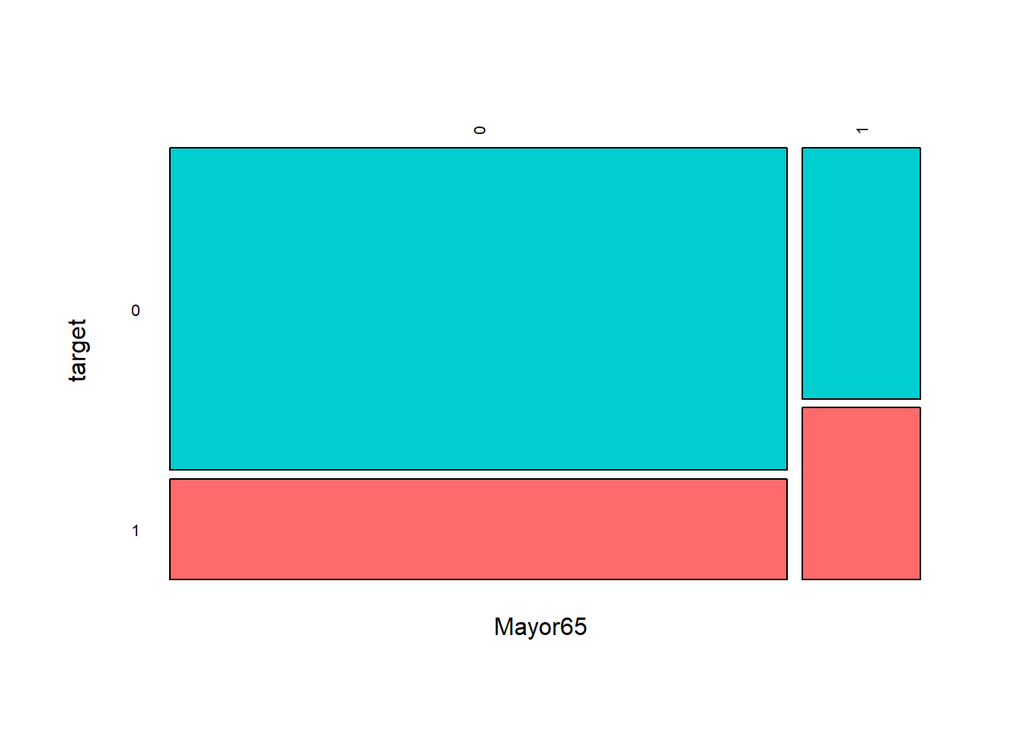

```r
m9<-mosaico_targetbinaria(input$Mayor65,varObjBin,"Mayor65")
```

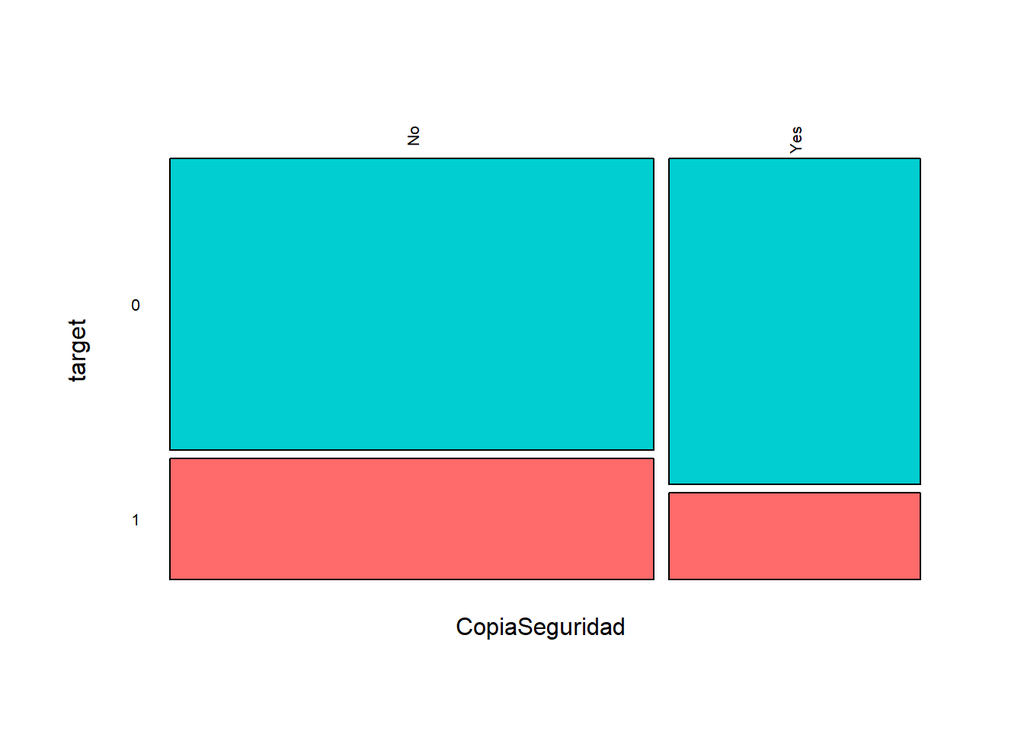

```r
m10<-mosaico_targetbinaria(input$CopiaSeguridad,varObjBin,"CopiaSeguridad")
```

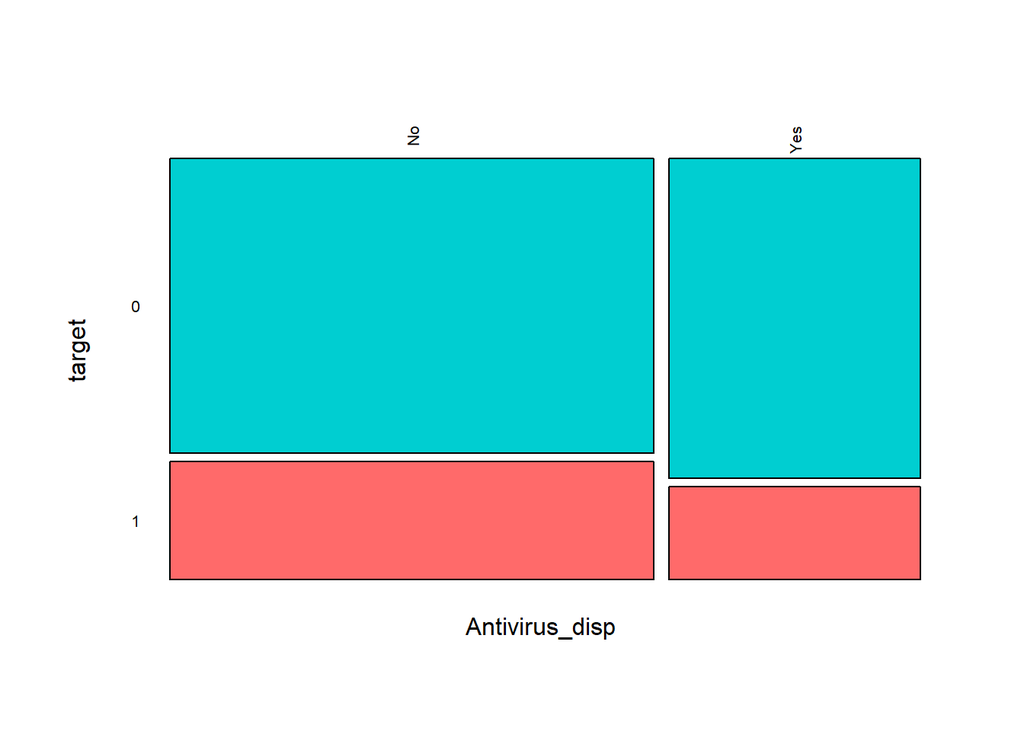

```r
m11<-mosaico_targetbinaria(input$Antivirus_disp,varObjBin,"Antivirus_disp")
```

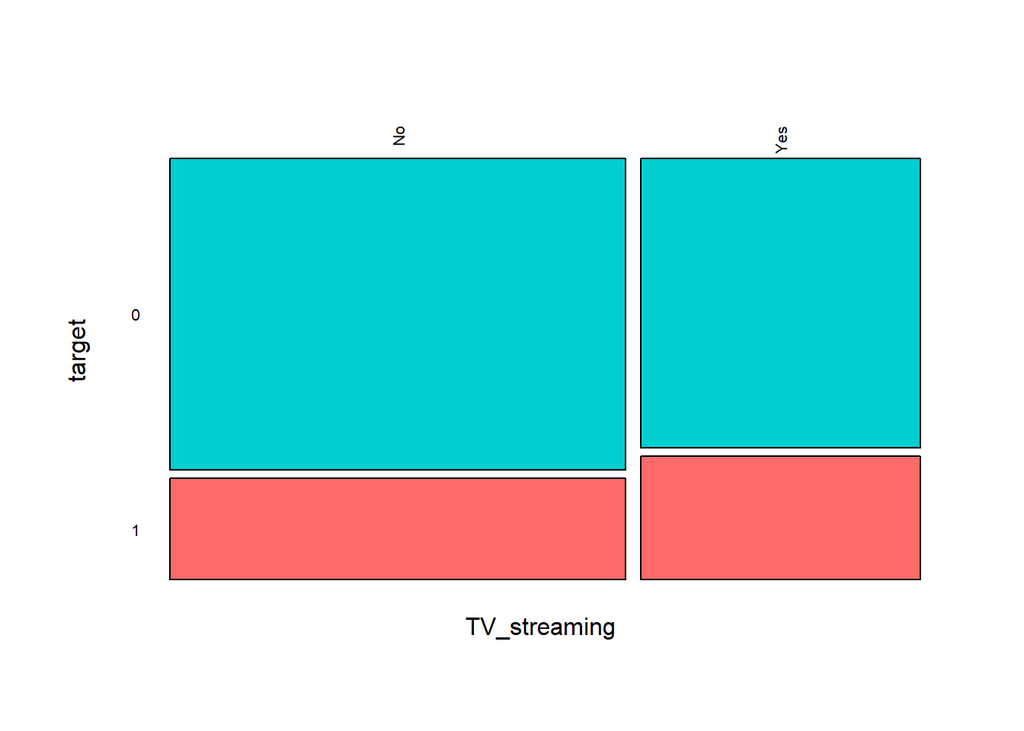

```r
m12<-mosaico_targetbinaria(input$TV_streaming,varObjBin,"TV_streaming")
```

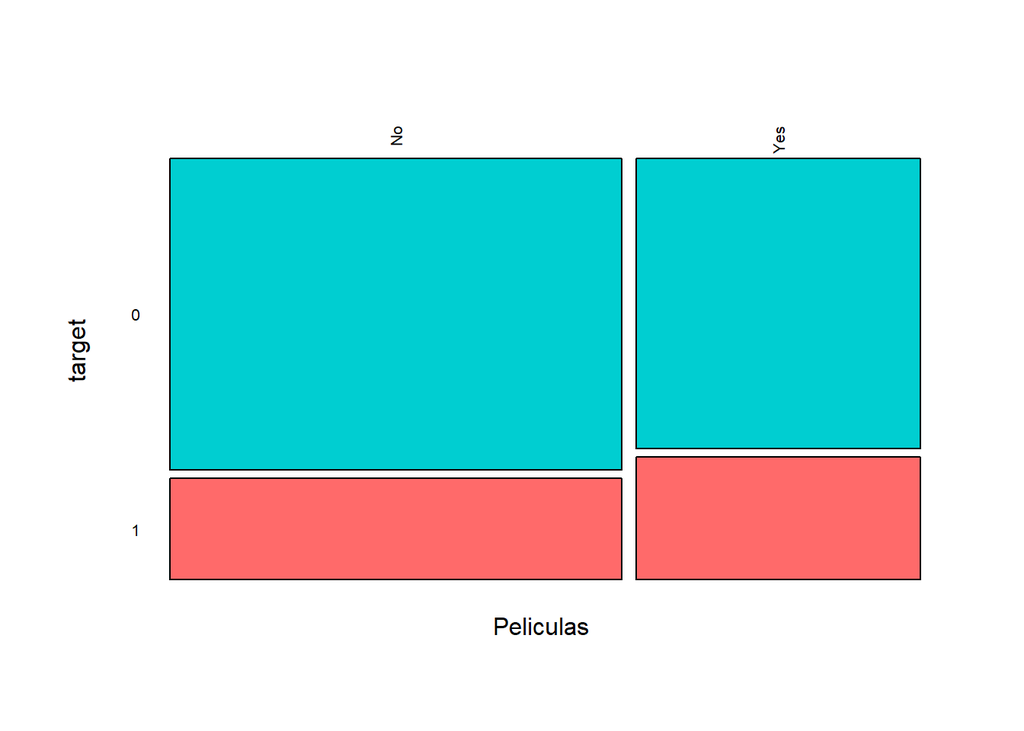

```r
m13<-mosaico_targetbinaria(input$Peliculas,varObjBin,"Peliculas")
```

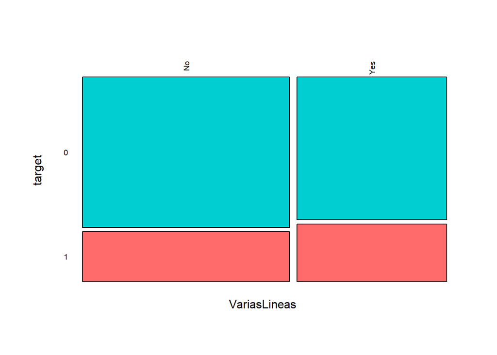

```r
m14<-mosaico_targetbinaria(input$VariasLineas,varObjBin,"VariasLineas")
```

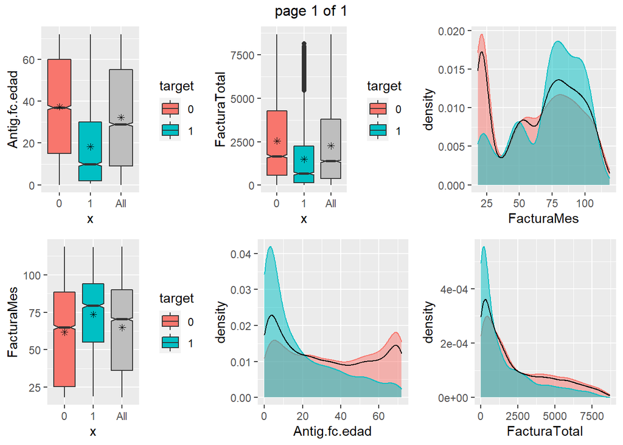

```r
#Veo gráficamente el efecto de dos variables cuantitativas sobre la binaria
bx1<-boxplot_targetbinaria(input$Antig.fc.edad,varObjBin,"Antig.fc.edad")
bx2<-boxplot_targetbinaria(input$FacturaMes,varObjBin,"FacturaMes")
bx3<-boxplot_targetbinaria(input$FacturaTotal,varObjBin,"FacturaTotal")


h1<-hist_targetbinaria(input$Antig.fc.edad,varObjBin,"Antig.fc.edad")
h2<-hist_targetbinaria(input$FacturaMes,varObjBin,"FacturaMes")
h3<-hist_targetbinaria(input$FacturaTotal,varObjBin,"FacturaTotal")

marrangeGrob(list(bx1,bx2,bx3,h1,h2,h3),nrow = 2,ncol = 3)
```

## transformaciones

```r
#Busco las mejores transformaciones para las variables numéricas con respecto a la variable binaria
input_bin<-cbind(input,Transf_Auto(Filter(is.numeric, subset(input, select = -(prop_missings))),varObjBin))

#Guardamos el dataset con las tranformaciones
todo_bin<-data.frame(input_bin,varObjBin)
saveRDS(todo_bin,"todo_bin_fuga.RDS")
```

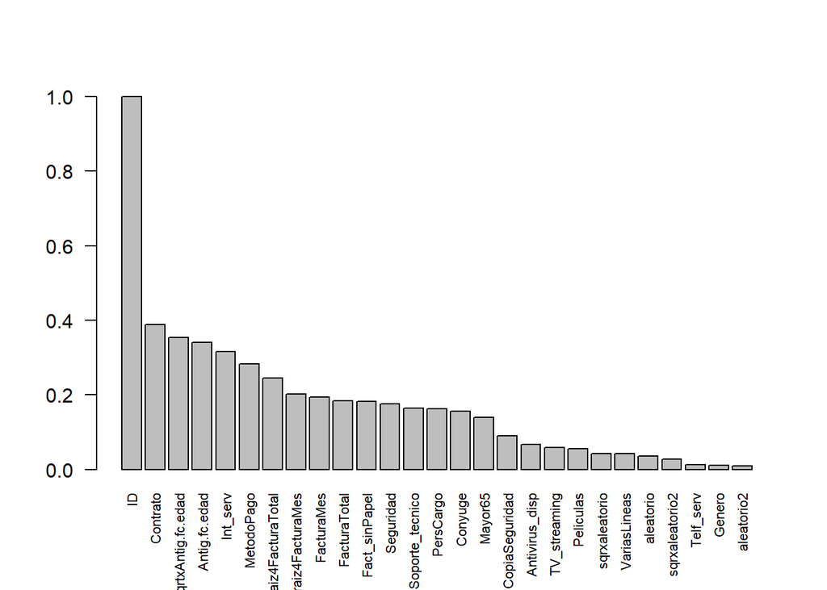

```r
graficoVcramer(input_bin,varObjBin)
```

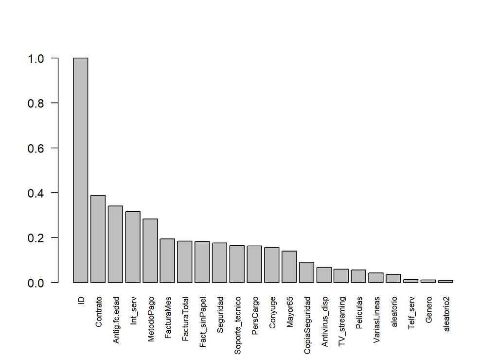

```r
graficoVcramer(input,varObjBin)
```

```r
todo<-todo_bin
freq(todo$varObjBin) #error de referencia
```

```
##      n    % val%
## 0 4667 73.5 73.5
## 1 1686 26.5 26.5
```

```r
names(todo)
```

```
##  [1] "ID"                 "Genero"             "Mayor65"
##  [4] "Conyuge"            "PersCargo"          "Antig.fc.edad"
##  [7] "Telf_serv"          "VariasLineas"       "Int_serv"
## [10] "Seguridad"          "CopiaSeguridad"     "Antivirus_disp"
## [13] "Soporte_tecnico"    "TV_streaming"       "Peliculas"
## [16] "Contrato"           "Fact_sinPapel"      "MetodoPago"
## [19] "FacturaMes"         "FacturaTotal"       "prop_missings"
## [22] "aleatorio"          "aleatorio2"         "sqrtxAntig.fc.edad"
## [25] "raiz4FacturaMes"    "raiz4FacturaTotal"  "sqrxaleatorio"
## [28] "sqrxaleatorio2"     "varObjBin"
```

## partición y modelos manuales

Se realiza manualmente la modelización. Luego de de la modelización incial, primero se toman los top4 según el pseudoR2, luego los top8. Basándose en el modelo top8, se busca manualmente mejorar el modelo.

```r
set.seed(1)
trainIndex <- createDataPartition(todo$varObjBin, p=0.8, list=FALSE)
data_train <- todo[trainIndex,c(1:23,29)]
data_test <- todo[-trainIndex,c(1:23,29)]
```

```r
modeloInicial<-glm(varObjBin~.,data=data_train[,-c(1,21)],family=binomial)
summary(modeloInicial)
```

```
##
## Call:
## glm(formula = varObjBin ~ ., family = binomial, data = data_train[,
##     -c(1, 21)])
##
## Deviance Residuals:
##     Min       1Q   Median       3Q      Max
## -2.0019  -0.6715  -0.3109   0.6777   3.1063
##
## Coefficients:
##                                     Estimate Std. Error z value Pr(>|z|)
## (Intercept)                       -8.293e-02  2.305e-01  -0.360 0.718998
## GeneroMale                        -2.376e-02  7.866e-02  -0.302 0.762603
## GeneroPreferNotSay                 2.052e-01  1.718e-01   1.194 0.232483
## Mayor651                           1.382e-01  1.016e-01   1.360 0.173794
## ConyugeYes                        -8.684e-02  9.124e-02  -0.952 0.341227
## PersCargoYes                      -1.874e-01  1.051e-01  -1.782 0.074776 .
## Antig.fc.edad                     -2.912e-02  4.003e-03  -7.275 3.47e-13 ***
## Telf_servYes                      -5.256e-01  1.621e-01  -3.243 0.001183 **
## VariasLineasYes                    2.866e-01  9.605e-02   2.983 0.002850 **
## Int_servFiber optic                9.028e-01  1.319e-01   6.846 7.57e-12 ***
## Int_servNo                        -5.736e-01  1.706e-01  -3.361 0.000777 ***
## SeguridadYes                      -3.792e-01  1.022e-01  -3.709 0.000208 ***
## CopiaSeguridadYes                 -2.057e-01  9.382e-02  -2.192 0.028369 *
## Antivirus_dispYes                  5.124e-02  9.565e-02   0.536 0.592157
## Soporte_tecnicoYes                -3.816e-01  1.011e-01  -3.775 0.000160 ***
## TV_streamingYes                    2.609e-01  1.030e-01   2.533 0.011306 *
## PeliculasYes                       2.448e-01  1.023e-01   2.392 0.016772 *
## ContratoOne year                  -7.180e-01  1.215e-01  -5.911 3.40e-09 ***
## ContratoTwo year                  -1.204e+00  1.698e-01  -7.091 1.33e-12 ***
## Fact_sinPapelYes                   4.333e-01  8.559e-02   5.063 4.14e-07 ***
## MetodoPagoCredit card (automatic) -3.048e-01  1.306e-01  -2.334 0.019587 *
## MetodoPagoElectronic check         3.105e-01  1.081e-01   2.873 0.004066 **
## MetodoPagoMailed check            -1.665e-01  1.293e-01  -1.288 0.197612
## FacturaMes                         2.216e-03  3.604e-03   0.615 0.538651
## FacturaTotal                      -5.921e-05  5.074e-05  -1.167 0.243297
## aleatorio                         -1.989e-01  1.311e-01  -1.517 0.129235
## aleatorio2                        -9.622e-02  1.293e-01  -0.744 0.456822
## ---
## Signif. codes:  0 '***' 0.001 '**' 0.01 '*' 0.05 '.' 0.1 ' ' 1
##
## (Dispersion parameter for binomial family taken to be 1)
##
##     Null deviance: 5882.3  on 5082  degrees of freedom
## Residual deviance: 4253.9  on 5056  degrees of freedom
## AIC: 4307.9
##
## Number of Fisher Scoring iterations: 6
```

```r
table(todo$Contrato,todo$varObjBin)
```

```
##
##                     0    1
##   Month-to-month 2032 1465
##   One year       1185  156
##   Two year       1450   65
```

```r
table(data_train$Contrato,data_train$varObjBin)
```

```
##
##                     0    1
##   Month-to-month 1635 1175
##   One year        950  122
##   Two year       1149   52
```

Luego de ver las tablas, se decide que no se justifica unir categorías, ya que implicaría en este caso eliminar la variable.

```r
pseudoR2(modeloInicial,data_train,"varObjBin")
```

```
## [1] 0.2768378
```

```r
pseudoR2(modeloInicial,data_test,"varObjBin")
```

```
## [1] 0.2812135
```

```r
modeloInicial$rank #número de parámetros
```

```
## [1] 27
```

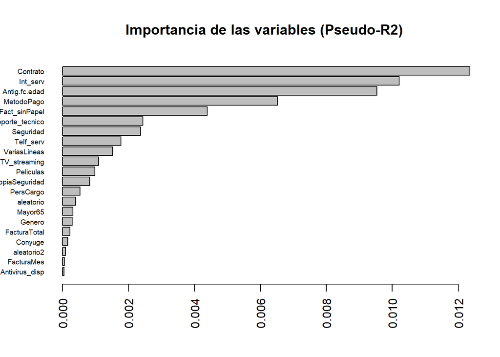

```r
impVariablesLog(modeloInicial,"varObjBin"
                )
```

Consideramos las cuatro primeras

```r
modelotop4<-glm(varObjBin~Contrato+Int_serv+Antig.fc.edad+MetodoPago,
             data=data_train,family=binomial)
summary(modelotop4)
```

```
##
## Call:
## glm(formula = varObjBin ~ Contrato + Int_serv + Antig.fc.edad +
##     MetodoPago, family = binomial, data = data_train)
##
## Deviance Residuals:
##     Min       1Q   Median       3Q      Max
## -1.6728  -0.6882  -0.3301   0.7529   3.0244
##
## Coefficients:
##                                    Estimate Std. Error z value Pr(>|z|)
## (Intercept)                       -0.374961   0.114997  -3.261  0.00111 **
## ContratoOne year                  -0.824141   0.116605  -7.068 1.57e-12 ***
## ContratoTwo year                  -1.385846   0.163359  -8.483  < 2e-16 ***
## Int_servFiber optic                1.088062   0.086223  12.619  < 2e-16 ***
## Int_servNo                        -0.709603   0.134305  -5.284 1.27e-07 ***
## Antig.fc.edad                     -0.031486   0.002162 -14.562  < 2e-16 ***
## MetodoPagoCredit card (automatic) -0.274092   0.127551  -2.149  0.03164 *
## MetodoPagoElectronic check         0.434025   0.105220   4.125 3.71e-05 ***
## MetodoPagoMailed check            -0.234983   0.125874  -1.867  0.06193 .
## ---
## Signif. codes:  0 '***' 0.001 '**' 0.01 '*' 0.05 '.' 0.1 ' ' 1
##
## (Dispersion parameter for binomial family taken to be 1)
##
##     Null deviance: 5882.3  on 5082  degrees of freedom
## Residual deviance: 4393.2  on 5074  degrees of freedom
## AIC: 4411.2
##
## Number of Fisher Scoring iterations: 6
```

```r
pseudoR2(modelotop4,data_train,"varObjBin")
```

```
## [1] 0.2531522
```

```r
pseudoR2(modelotop4,data_test,"varObjBin")
```

```
## [1] 0.2659774
```

```r
modelotop4$rank
```

```
## [1] 9
```

Consideramos las 8 primeras

```r
modelotop8<-glm(varObjBin~Contrato+Int_serv+Antig.fc.edad+MetodoPago+Fact_sinPapel+Soporte_tecnico+Seguridad+Telf_serv,
             data=data_train,family=binomial)
summary(modelotop8)
```

```
##
## Call:
## glm(formula = varObjBin ~ Contrato + Int_serv + Antig.fc.edad +
##     MetodoPago + Fact_sinPapel + Soporte_tecnico + Seguridad +
##     Telf_serv, family = binomial, data = data_train)
##
## Deviance Residuals:
##     Min       1Q   Median       3Q      Max
## -1.7542  -0.6713  -0.3194   0.7045   3.1564
##
## Coefficients:
##                                    Estimate Std. Error z value Pr(>|z|)
## (Intercept)                       -0.134313   0.163863  -0.820 0.412406
## ContratoOne year                  -0.707093   0.118502  -5.967 2.42e-09 ***
## ContratoTwo year                  -1.197861   0.166780  -7.182 6.86e-13 ***
## Int_servFiber optic                1.093438   0.100933  10.833  < 2e-16 ***
## Int_servNo                        -0.719383   0.149309  -4.818 1.45e-06 ***
## Antig.fc.edad                     -0.029947   0.002214 -13.525  < 2e-16 ***
## MetodoPagoCredit card (automatic) -0.304226   0.129338  -2.352 0.018664 *
## MetodoPagoElectronic check         0.350147   0.106797   3.279 0.001043 **
## MetodoPagoMailed check            -0.213216   0.127663  -1.670 0.094891 .
## Fact_sinPapelYes                   0.483516   0.084511   5.721 1.06e-08 ***
## Soporte_tecnicoYes                -0.359821   0.096829  -3.716 0.000202 ***
## SeguridadYes                      -0.416229   0.098526  -4.225 2.39e-05 ***
## Telf_servYes                      -0.465809   0.141654  -3.288 0.001008 **
## ---
## Signif. codes:  0 '***' 0.001 '**' 0.01 '*' 0.05 '.' 0.1 ' ' 1
##
## (Dispersion parameter for binomial family taken to be 1)
##
##     Null deviance: 5882.3  on 5082  degrees of freedom
## Residual deviance: 4310.1  on 5070  degrees of freedom
## AIC: 4336.1
##
## Number of Fisher Scoring iterations: 6
```

```r
pseudoR2(modelotop8,data_train,"varObjBin")
```

```
## [1] 0.2672803
```

```r
pseudoR2(modelotop8,data_test,"varObjBin")
```

```
## [1] 0.2754168
```

```r
modelotop8$rank
```

```
## [1] 13
```

Comprobamos interacciones

```r
modelotop8a<-glm(varObjBin~Contrato+Int_serv+Antig.fc.edad+MetodoPago+Fact_sinPapel+Soporte_tecnico+Seguridad+Telf_serv+Antig.fc.edad*MetodoPago+Antig.fc.edad*Soporte_tecnico,
             data=data_train,family=binomial)
summary(modelotop8a)
pseudoR2(modelotop8a,data_train,"varObjBin")
pseudoR2(modelotop8a,data_test,"varObjBin")
modelotop8a$rank
```

No mejora y las interacciones tiene pvalores muy altos.

Comprobamos otras interacciones

```r
modelotop8b<-glm(varObjBin~Contrato+Int_serv+Antig.fc.edad+MetodoPago+Fact_sinPapel+Soporte_tecnico+Seguridad+Telf_serv+Contrato*Antig.fc.edad+Contrato*MetodoPago+Contrato*Soporte_tecnico,
             data=data_train,family=binomial)
summary(modelotop8b)
pseudoR2(modelotop8b,data_train,"varObjBin")
pseudoR2(modelotop8b,data_test,"varObjBin")
modelotop8b$rank
```

No mejora más que centésimas pero tenemos dos relaciones estrelladas. Removemos Contrato:MetodoPago

```r
modelotop8c<-glm(varObjBin~Contrato+Int_serv+Antig.fc.edad+MetodoPago+Fact_sinPapel+Soporte_tecnico+Seguridad+Telf_serv+Contrato*Antig.fc.edad+Contrato*Soporte_tecnico,
             data=data_train,family=binomial)
summary(modelotop8c)
pseudoR2(modelotop8c,data_train,"varObjBin")
pseudoR2(modelotop8c,data_test,"varObjBin")
modelotop8c$rank
```

El modelo es prácticamente el mismo que el anterior.

Intentaremos agregar la relación MetodoPago:Factura_sinPapel

```r
modelotop8d<-glm(varObjBin~Contrato+Int_serv+Antig.fc.edad+MetodoPago+Fact_sinPapel+Soporte_tecnico+Seguridad+Telf_serv+Contrato*Antig.fc.edad+Contrato*Soporte_tecnico+MetodoPago*Fact_sinPapel,
             data=data_train,family=binomial)
summary(modelotop8d)
pseudoR2(modelotop8d,data_train,"varObjBin")
pseudoR2(modelotop8d,data_test,"varObjBin")
modelotop8d$rank
```

Seguimos cerca de los mismos valores. Agregamos Int_serv:Telf_serv

```r
modelotop8e<-glm(varObjBin~Contrato+Int_serv+Antig.fc.edad+MetodoPago+Fact_sinPapel+Soporte_tecnico+Seguridad+Telf_serv+Contrato*Antig.fc.edad+Contrato*Soporte_tecnico+Int_serv*Telf_serv,
             data=data_train,family=binomial)
summary(modelotop8e)
pseudoR2(modelotop8e,data_train,"varObjBin")
pseudoR2(modelotop8e,data_test,"varObjBin")
modelotop8e$rank
```

Seguimos cerca de los mismos valores. Se pierde la significancia de Int_serv (por sí misma)

Exploramos relación servicio con soporte técnico

```r
modelotop8f<-glm(varObjBin~Contrato+Int_serv+Antig.fc.edad+MetodoPago+Fact_sinPapel+Soporte_tecnico+Seguridad+Telf_serv+Contrato*Antig.fc.edad+Contrato*Soporte_tecnico+Int_serv*Soporte_tecnico+Telf_serv*Soporte_tecnico,
             data=data_train,family=binomial)
summary(modelotop8f)
pseudoR2(modelotop8f,data_train,"varObjBin")
pseudoR2(modelotop8f,data_test,"varObjBin")
modelotop8f$rank
```

Mejoro centésimas en test. Parece que sólo por la relación int:soporte. Quitamos telf:soporte

```r
modelotop8g<-glm(varObjBin~Contrato+Int_serv+Antig.fc.edad+MetodoPago+Fact_sinPapel+Soporte_tecnico+Seguridad+Telf_serv+Contrato*Antig.fc.edad+Contrato*Soporte_tecnico+Int_serv*Soporte_tecnico,
             data=data_train,family=binomial)
summary(modelotop8g)
pseudoR2(modelotop8g,data_train,"varObjBin")
pseudoR2(modelotop8g,data_test,"varObjBin")
modelotop8g$rank
```

Es prácticamente igual con una variable menos que el anterior. Apenas unas centésimas más.

```r
modelotop8h<-glm(varObjBin~Contrato+Int_serv+Antig.fc.edad+MetodoPago+Fact_sinPapel+Soporte_tecnico+Seguridad+Telf_serv+Contrato*Antig.fc.edad+Contrato*Soporte_tecnico,
             data=data_train,family=binomial)
summary(modelotop8h)
pseudoR2(modelotop8h,data_train,"varObjBin")
pseudoR2(modelotop8h,data_test,"varObjBin")
modelotop8h$rank
```

No hay cambio significativo, pero tenemos dos variables menos que el anterior.

## comparación de modelos

Se comparan todos los modelos anteriores por validación cruzada según la métrica ROC.

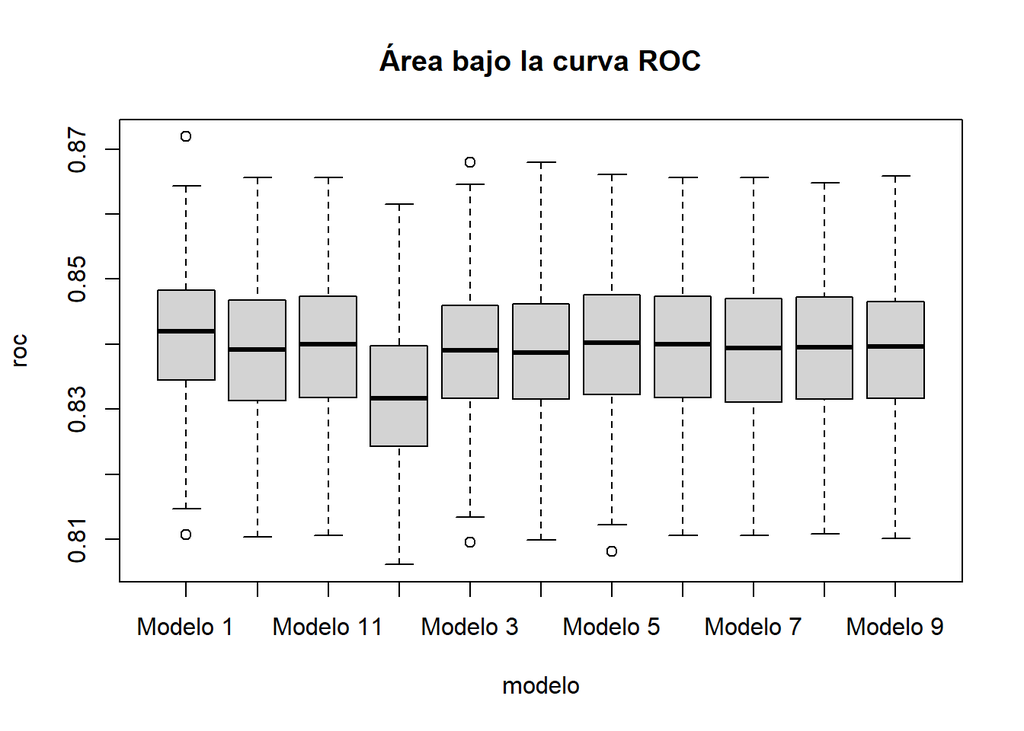

```r
#copia de la variable original
auxVarObj<-todo$varObjBin

#formateo la variable objetivo para que funcione el codigo
todo$varObjBin<-make.names(todo$varObjBin)

total<-c()
modelos<-sapply(list(modeloInicial,modelotop4,modelotop8,modelotop8a,modelotop8b,modelotop8c,modelotop8d,modelotop8e,modelotop8f,modelotop8g,modelotop8h),formula)
for (i in 1:length(modelos)){
  set.seed(1712)
  vcr<-train(as.formula(modelos[[i]]), data = todo,
             method = "glm", family="binomial",metric = "ROC",
             trControl = trainControl(method="repeatedcv", number=5, repeats=20,
                                      summaryFunction=twoClassSummary,
                                      classProbs=TRUE,returnResamp="all")
  )
  total<-rbind(total,data.frame(roc=vcr$resample[,1],modelo=rep(paste("Modelo",i)),
                                                                  nrow(vcr$resample)))
}
boxplot(roc~modelo,data=total,main="Área bajo la curva ROC")
```

son todos prácticamente iguales salvo el modelo 2 que corresponde al modelotop4.

```r
aggregate(roc~modelo, data = total, mean)
```

```
##       modelo       roc
## 1   Modelo 1 0.8407813
## 2  Modelo 10 0.8385743
## 3  Modelo 11 0.8390940
## 4   Modelo 2 0.8318904
## 5   Modelo 3 0.8384913
## 6   Modelo 4 0.8383284
## 7   Modelo 5 0.8393112
## 8   Modelo 6 0.8390940
## 9   Modelo 7 0.8386668
## 10  Modelo 8 0.8388722
## 11  Modelo 9 0.8386908
```

```r
aggregate(roc~modelo, data = total, sd)
```

```
##       modelo        roc
## 1   Modelo 1 0.01132740
## 2  Modelo 10 0.01176932
## 3  Modelo 11 0.01172946
## 4   Modelo 2 0.01168162
## 5   Modelo 3 0.01180466
## 6   Modelo 4 0.01185628
## 7   Modelo 5 0.01175295
## 8   Modelo 6 0.01172946
## 9   Modelo 7 0.01178032
## 10  Modelo 8 0.01171779
## 11  Modelo 9 0.01166149
```

```r
#recupero la variable objetivo en su formato
todo$varObjBin<-auxVarObj

#miro el numero de parametros
modeloInicial$rank
```

```
## [1] 27
```

```r
modelotop4$rank
```

```
## [1] 9
```

```r
modelotop8$rank
```

```
## [1] 13
```

```r
modelotop8a$rank
```

```
## [1] 17
```

```r
modelotop8b$rank
```

```
## [1] 23
```

```r
modelotop8c$rank
```

```
## [1] 17
```

```r
modelotop8d$rank
```

```
## [1] 20
```

```r
modelotop8e$rank
```

```
## [1] 19
```

```r
modelotop8f$rank
```

```
## [1] 20
```

```r
modelotop8g$rank
```

```
## [1] 19
```

```r
modelotop8h$rank
```

```
## [1] 17
```

```r
modelotop8c$rank
```

```
## [1] 17
```

```r
modelotop8f$rank
```

```
## [1] 20
```

```r
modelotop8g$rank
```

```
## [1] 19
```

y de estos tres tomamos el que menos variables tiene, es decir: modelotop8c (el modelo6 en la gráfica)

Sin embargo aún son muchas variables: podríamos tomar el modelo3 = modelotop8. Este modelo no tiene interrelaciones, a la vez que solo tiene 13 variables, con un roc apenas inferior al modelotop8c.

```r
modelotop8$rank
```

```
## [1] 13
```